# Practical Machine Learning Project

ssendhil

7/7/2019

# Background

Using devices such as Jawbone Up, Nike FuelBand, and Fitbit it is now possible to collect a large amount of data about personal activity relatively inexpensively. These type of devices are part of the quantified self movement – a group of enthusiasts who take measurements about themselves regularly to improve their health, to find patterns in their behavior, or because they are tech geeks. One thing that people regularly do is quantify how much of a particular activity they do, but they rarely quantify how well they do it. In this project, your goal will be to use data from accelerometers on the belt, forearm, arm, and dumbell of 6 participants. They were asked to perform barbell lifts correctly and incorrectly in 5 different ways. More information is available from the website here: http://web.archive.org/web/20161224072740/http:/groupware.les.inf.puc-rio.br/har (see the section on the Weight Lifting Exercise Dataset).

# Goal

The goal of this project is to predict the manner in which participants exercised. This is the “classe” variable in the training set. You may use any of the other variables to predict with. You should create a report describing how you built your model, how you used cross validation, what you think the expected out of sample error is, and why you made the choices you did. You will also use your prediction model to predict 20 different test cases.

# Modeling strategy and results

First, I cleaned the data by removing variables with large amounts (> 85%) of missing values, either blanks or NAs. Then, I randomly split the training data into two sets: “train” and “test”. The new train dataset has 70% of the cleaned training data while the new test dataset has the remaining 30%. Then, I used three different modeling methods: decision trees, randomForest, and Gradient Boosting. I used all predictors possible for each method. Whichever model has the highest accuracy in predicting the 30% of new “test” cases will be the model used to predict the 20 test cases for the final quiz.

The results were as follows:

1. Decision tree success rate: **~50%**
2. Random Forest success rate: **~99%**
3. Gradient Boosting Model success rate: **~96%**

**The OOB sample error is 0.5%**

# Load data

```r
library(caret)
library(gbm)
```

```r
library(knitr)
library(randomForest)

# set the URL for the download
training_url <- "http://d396qusza40orc.cloudfront.net/predmachlearn/pml-training.csv"
test_url  <- "http://d396qusza40orc.cloudfront.net/predmachlearn/pml-testing.csv"

# download the datasets
training_data <- read.csv(training_url)
testing_data  <- read.csv(test_url)

dim(training_data)
```

```
## [1] 19622   160
```

```r
dim(testing_data)
```

```
## [1]  20 160
```

# Subset necessary variables for the model

Remove variables with at least 85% of missing values in the training dataset (NAs or blanks)

```r
remove_cols <- which(colSums(is.na(training_data) | training_data=="") > 0.85 * nrow(training_data))

training_data_clean <- training_data[,-c(1:7,remove_cols)]

dim(training_data_clean)
```

```
## [1] 19622    53
```

# Split training data into new train & test datasets for model development

**Randomly select 70% of cleaned training data to make new “train” dataset (remaining 30% will be test sample)**

```r
n <- nrow(training_data_clean)

set.seed(1234567)
train_rows <- sample(1:n,round(0.7*n),replace=F)

train <- training_data_clean[train_rows, ]
test <- training_data_clean[-train_rows, ]

dim(train)
```

```
## [1] 13735    53
```

```r
dim(test)
```

```
## [1] 5887   53
```

# Model 1: Predicting with Trees

```r
set.seed(23829427)
tC <- trainControl(method="cv", number=4)
tree_model_1 <- train(classe~., data=train, method="rpart", trControl=tC)

prediction_tree <- predict(tree_model_1,newdata=test)

confusion_matrix_model1 <- confusionMatrix(prediction_tree, test$classe)
confusion_matrix_model1$table
```

```
##           Reference
## Prediction    A    B    C    D    E
##          A 1531  462  472  449  145
##          B   26  393   27  169  152
##          C  121  275  528  348  298
##          D    0    0    0    0    0
##          E    2    0    0    0  489
```

```r
confusion_matrix_model1$overall[1] #accuracy
```

```
##  Accuracy
## 0.4995753
```

**The trees are only about 50% accurate with predictions. Likely not a trustworthy model for final predictions**

# Model 2: Predicting with Random Forest

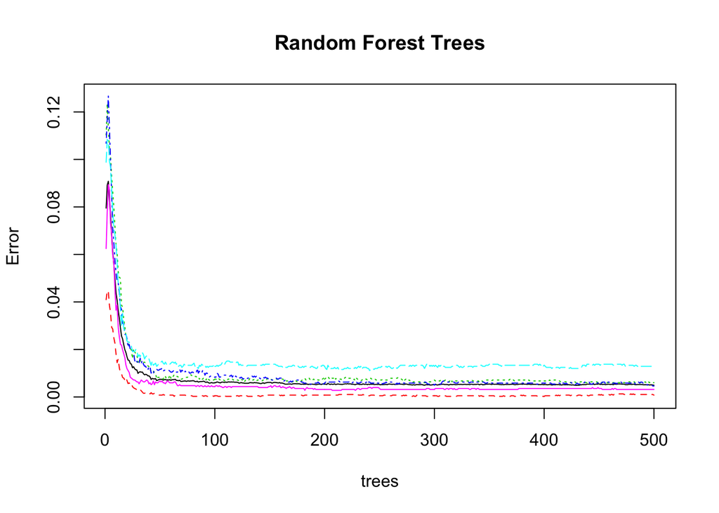

```r
set.seed(98765477)
rf_model_2 <- randomForest(formula = classe ~ ., data = train)
plot(rf_model_2, main="Random Forest Trees")
```

```r
prediction_rf <- predict(rf_model_2, newdata=test)

confusion_matrix_model2 <- confusionMatrix(prediction_rf, test$classe)
confusion_matrix_model2$table
```

```
##           Reference
## Prediction    A    B    C    D    E
##          A 1680    2    0    0    0
##          B    0 1122    3    0    0
##          C    0    5 1023    9    0
##          D    0    1    1  957    5
##          E    0    0    0    0 1079
```

```r
confusion_matrix_model2$overall[1] #accuracy
```

```
##  Accuracy
## 0.9955835
```

**The randomForest model is over 99% accurate with predictions. Likely the best model for final predictions. The plot tells us that about 100 trees is enough for the random forest model**

# Model 3: Predicting with Gradient Boost Model

```r
set.seed(29374637)

tC_gbm <- trainControl(method = "repeatedcv", number = 5, repeats = 1)
gbm_model_3 <- train(classe ~ ., data=train, method = "gbm", trControl = tC_gbm, verbose = FALSE)

prediction_gbm <- predict(gbm_model_3, newdata=test)
confusion_matrix_model3 <- confusionMatrix(prediction_gbm, test$classe)
confusion_matrix_model3$table
```

```
##           Reference
## Prediction    A    B    C    D    E
##          A 1650   45    0    1    1
##          B   19 1049   23    0   14
##          C    4   35  993   37    6
##          D    7    0   11  914   12
##          E    0    1    0   14 1051
```

```r
confusion_matrix_model3$overall[1] #accuracy
```

```
##  Accuracy
## 0.9609309
```

**The Gradient Boost model is 96% accurate with predictions. Not as successful as randomForest.**

# Conclusion

Because the model with the highest success rate is the randomForest, we will use that to make the final predictions of our 20 test cases. The output of the random forest model below indicates that **the OOB estimate for sample error is 0.5%**

```r
rf_model_2
```

```
##
## Call:
##  randomForest(formula = classe ~ ., data = train)
##                Type of random forest: classification
##                      Number of trees: 500
## No. of variables tried at each split: 7
##
##         OOB estimate of  error rate: 0.5%
## Confusion matrix:
##      A    B    C    D    E  class.error
## A 3897    3    0    0    0 0.0007692308
## B   12 2651    4    0    0 0.0059992501
## C    0    9 2384    2    0 0.0045929019
## D    1    0   27 2220    2 0.0133333333
## E    0    0    1    7 2515 0.0031708284
```

### Final model predictions for 20 test cases (RandomForest):

```r
predict(rf_model_2, newdata=testing_data)
```

```
##  1  2  3  4  5  6  7  8  9 10 11 12 13 14 15 16 17 18 19 20
##  B  A  B  A  A  E  D  B  A  A  B  C  B  A  E  E  A  B  B  B
## Levels: A B C D E
```